# Additional wrangling practice

Allison Horst, Casey O’Hara

### Objectives

- Reminders of reproducible workflows
- Review some data wrangling basics (dplyr & tidyr)
- Introduce a couple new functions (separate, unite, drop_na, rename, relocate)
- Remember ggplot?
- A map in R

### Attach packages

In the setup chunk in your RMarkdown document, attach the following packages:

- `tidyverse`
- `here`
- `sf`
- `tmap`

*Note: you may need to install these packages if you don’t already have them (recall: `install.packages("packagename")`)

```r
knitr::opts_chunk$set(echo = TRUE, message = FALSE, warning = FALSE)
```

```r
library(tidyverse)
library(here)
library(sf)
library(tmap)
```

### Read in the data

The data you’ll use (to start) is within the `data/sf_trees` subfolder. Use the `here` package to read in the `sf_trees.csv` file.

```r
sf_trees <- read_csv(here("data", "sf_trees", "sf_trees.csv"))
```

About the data: SF trees data are from the [SF Open Data Portal](https://data.sfgov.org/City-Infrastructure/Street-Tree-List/tkzw-k3nq). See more information from Thomas Mock and TidyTuesday [here](https://github.com/rfordatascience/tidytuesday/tree/master/data/2020/2020-01-28).

Check out the data using exploratory functions (e.g. `View()`, `names()`, `summary()`, etc.). Remember that those probably do **not** belong in your .Rmd code chunks (if you don’t need a record, you can either comment it out or put it in the Console).

### Part 1: Wrangling & ggplot review

**Example 1:** Find counts of observations by `legal_status` & wrangle a bit:

```r
# Way 1: group_by %>% summarize %>% n
sf_trees %>%
  group_by(legal_status) %>%
  summarize(mean_lat = mean(latitude, na.rm = TRUE),
            mean_lon = mean(longitude, na.rm = TRUE),
            tree_count = n())
```

```
## # A tibble: 10 × 4
##    legal_status                 mean_lat mean_lon tree_count
##    <chr>                           <dbl>    <dbl>      <int>
##  1 DPW Maintained                   37.8    -122.     141725
##  2 Landmark tree                    37.8    -122.         42
##  3 Permitted Site                   37.8    -122.      39732
##  4 Planning Code 138.1 required     37.8    -122.        971
##  5 Private                          37.8    -122.        163
##  6 Property Tree                    37.8    -122.        316
##  7 Section 143                      37.8    -122.        230
##  8 Significant Tree                 37.8    -122.       1648
##  9 Undocumented                     37.8    -122.       8106
## 10 <NA>                             37.8    -122.         54
```

```r
# Way 2: Same thing (+ a few other dplyr functions)
top_5_status <- sf_trees %>%
  drop_na(legal_status) %>%
  group_by(legal_status) %>%
  summarize(tree_count = n()) %>%
  slice_max(tree_count, n = 5) %>%
  arrange(-tree_count)
```

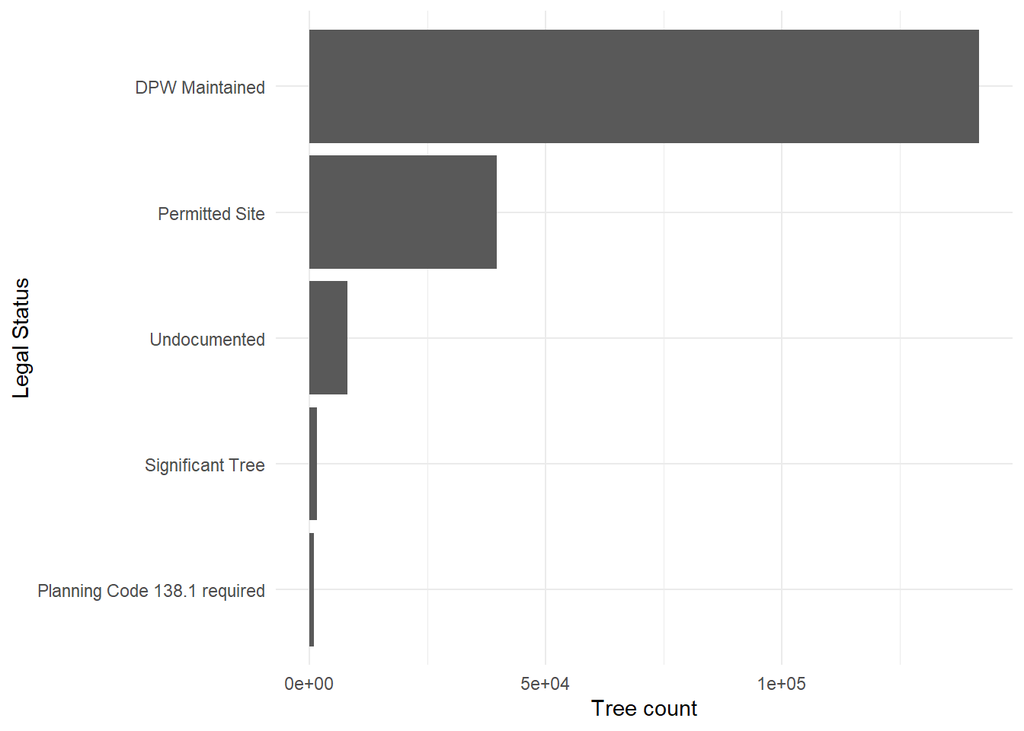

```r
ggplot(data = top_5_status,
       aes(x = fct_reorder(legal_status, tree_count),
           y = tree_count)) +
  geom_col() +
  labs(y = "Tree count", x = "Legal Status") +
  coord_flip() + ### note, in newer ggplot, can also just swap x and y in aes()
  theme_minimal()
```

**Example 2:** Only keep observations where legal status is `Permitted Site` and caretaker is `MTA`. Store as permitted_mta.

```r
permitted_mta <- sf_trees %>%
  filter(legal_status == "Permitted Site", caretaker == "MTA")
```

**Example 3:** Only keep Blackwood Acacia trees, then only keep columns `legal_status`, `date`, `latitude` and `longitude`. Store as `blackwood_acacia`.

The `stringr` package contains a bunch of useful functions for finding & working with strings (e.g. words). One is `str_detect()` to detect a specific string within in a column.

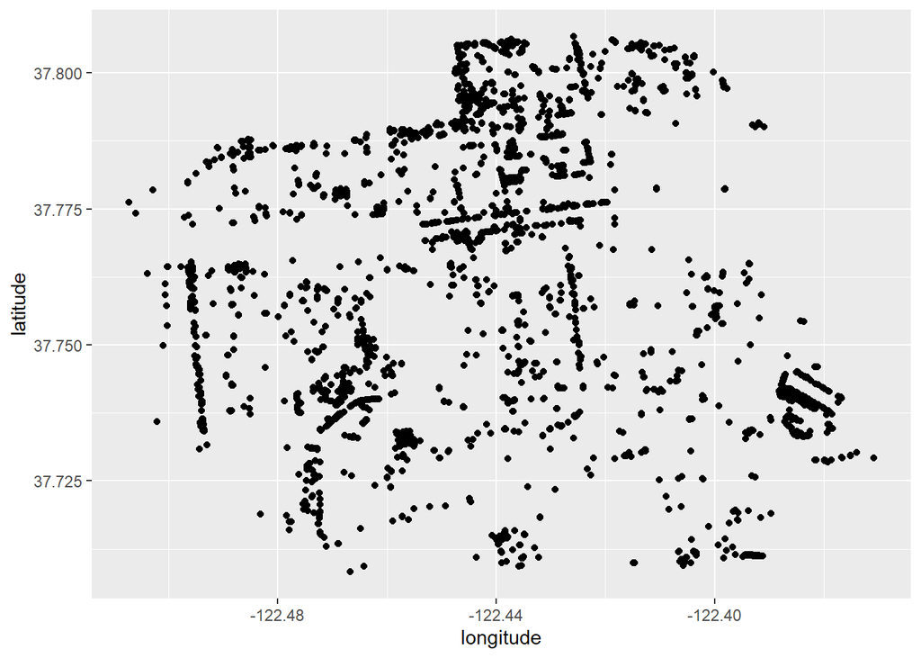

```r
blackwood_acacia <- sf_trees %>%
  filter(str_detect(species, "Blackwood Acacia")) %>%
  select(legal_status, date, latitude, longitude)

# Make a little graph of locations (note R doesn't know these are spatial)
ggplot(data = blackwood_acacia, aes(x = longitude, y = latitude)) +
  geom_point()
```

**Example 4:** Meet `tidyr::separate()`

Separate the `species` column into two separate columns: `spp_scientific` and `spp_common`

```r
sf_trees_sep <- sf_trees %>%
  separate(species, into = c("spp_scientific", "spp_common"), sep = " :: ")
```

**Example 5:** Meet `tidyr::unite()`

Yeah, it does the opposite. Unite the `tree_id` and `legal_status` columns, using a separator of “*COOL*” (no, you’d never actually do this…).

```r
ex_5 <- sf_trees %>%
  unite("id_status", tree_id:legal_status, sep = "_COOL_")
```

#### Stage, commit, pull, push to GitHub!

### Part 2: Make some actual maps

You need `sf` and `tmap` successfully attached to do this part. We’ll convert lat/lon to spatial data (see that now there’s a column called `geometry`), then we can use `geom_sf()` to plot.

**Step 1:** Convert the lat/lon to spatial points

Use `st_as_sf()` to convert to spatial coordinates (`_sf` suffix to remember that this is a simple features object; `sf_` prefix here still means San Francisco!):

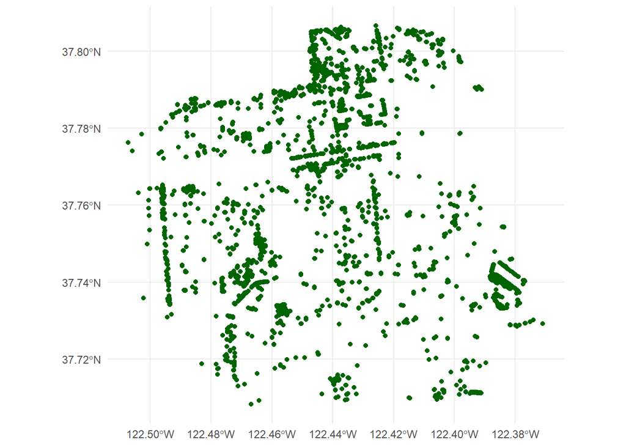

```r
blackwood_acacia_sf <- blackwood_acacia %>%
  drop_na(longitude, latitude) %>%
  st_as_sf(coords = c("longitude", "latitude")) # Convert to spatial coordinates

# But we need to set the coordinate reference system (CRS) so it's compatible with the street map of San Francisco we'll use as a "base layer":
st_crs(blackwood_acacia_sf) = 4326

# Then we can use `geom_sf`!

ggplot(data = blackwood_acacia_sf) +
  geom_sf(color = "darkgreen") +
  theme_minimal()
```

But that’s not especially useful unless we have an actual map of SF to plot this on, right?

Read in the SF shapefile (data/sf_map/tl_2017_06075_roads.shp):

```r
sf_map <- read_sf(here("data", "sf_map", "tl_2017_06075_roads.shp"))

st_transform(sf_map, 4326)
```

```
## Simple feature collection with 4087 features and 4 fields
## Geometry type: LINESTRING
## Dimension:     XY
## Bounding box:  xmin: -122.5136 ymin: 37.70813 xmax: -122.3496 ymax: 37.83213
## Geodetic CRS:  WGS 84
## # A tibble: 4,087 × 5
##    LINEARID      FULLNAME            RTTYP MTFCC                        geometry
##  * <chr>         <chr>               <chr> <chr>                <LINESTRING [°]>
##  1 110498938773  Hwy 101 S Off Rmp   M     S1400 (-122.4041 37.74842, -122.404 …
##  2 110498937425  Hwy 101 N on Rmp    M     S1400 (-122.4744 37.80691, -122.4746…
##  3 1103660229533 Ludlow Aly - No Acc M     S1780 (-122.4596 37.73853, -122.4596…
##  4 1106081811301 Mission Bay Blvd N  M     S1400 (-122.3946 37.77082, -122.3929…
##  5 1103666896385 25th Ave N          M     S1400 (-122.4858 37.78953, -122.4855…
##  6 1103689702566 Willard N           M     S1400 (-122.457 37.77817, -122.457 3…
##  7 1103689702762 25th Ave N          M     S1400 (-122.4858 37.78953, -122.4858…
##  8 110498933806  Avenue N            M     S1400 (-122.3643 37.81947, -122.3638…
##  9 1103689702763 25th Ave N          M     S1400 (-122.4854 37.78983, -122.4858…
## 10 1103677491290 Mission Bay Blvd S  M     S1400 (-122.3865 37.77086, -122.3878…
## # … with 4,077 more rows
```

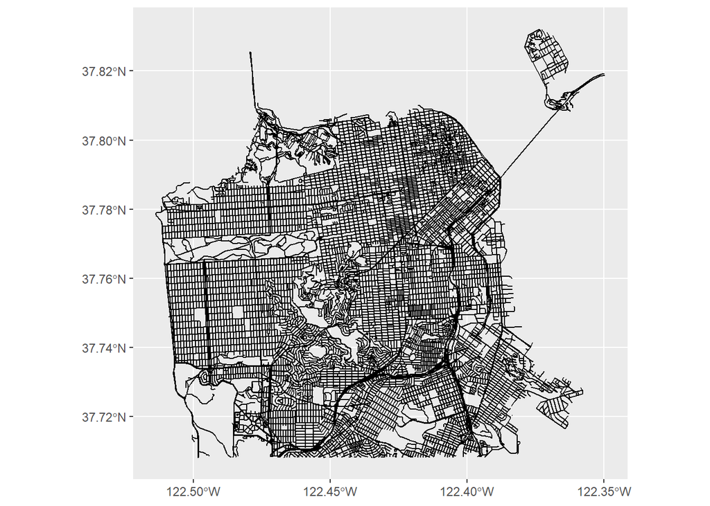

```r
ggplot(data = sf_map) +
  geom_sf()
```

Now combine them:

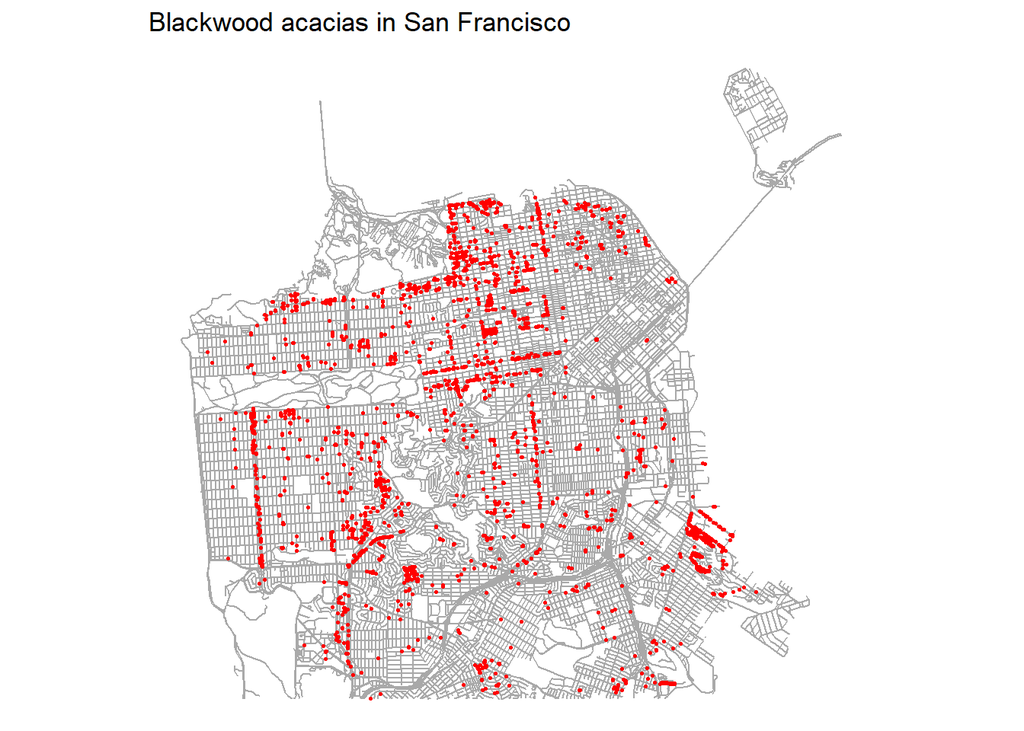

```r
ggplot() +
  geom_sf(data = sf_map,
          size = 0.1,
          color = "darkgray") +
  geom_sf(data = blackwood_acacia_sf,
          color = "red",
          size = 0.5) +
  theme_void() +
  labs(title = "Blackwood acacias in San Francisco")
```

### Now an interactive one!

```r
tmap_mode("view")

tm_shape(blackwood_acacia_sf) +
  tm_dots()
```

[interactive chart not shown]

### Wrap up:

Make sure you stage, commit, pull, then push back to GitHub. Done!